# Glassdoor Income Inequality Analysis

Exploring the relationships on how various factors such as gender, income, seniority, age, education affect income and bonus

Abigail Chen

## Research Questions

Part 1: How much do working women make compared to working men? Do we have analytical evidence surrounding the issue of salary inequality? What causes these inequalities? How is pay affected by various factors as seen in Glassdoor? How does seniority affect the wage? Can working women bridge the wage gap by getting more education?

Part 2: Which gender receives more bonuses men or women? Does seniority play a role in the bonuses a person can receive? Does the years of studying affect the extra pay a person gets?

## Introduction

According to the Workplace Gender Equality Agency (WGEA), the gender pay gap measures the difference between the average earnings of women and men in the workforce. This is an internationally established measure of working women’s position in our economy in comparison to working men. This project aims to explore the relationship between salary and gender based on the data from Glassdoor using regression analysis. As well as looking at the relationship between, For pay we will be looking at the net income and the bonus pay. Additionally, other factors such as age, seniority, level of education of an individual will also be taken into account.

## Motivation

According to the Workplace Gender Equality Agency (WGEA), the gender pay gap is influenced by a number of factors, including: conscious and unconscious discrimination and bias in hiring and pay decisions. women and men working in different industries and different jobs, with female-dominated industries and jobs attracting lower wages and high rates of part-time work for women.

Equality whether, socially, legally, mentally and even financially on the bases of gender are basic human rights, it’s meant to be a equal for everyone. This is important in sending a positive message about an organization’s values that are aligned with creating compensation systems that are transparent, fair and rewarding. This can then lead to attracting better employees, improving employee retention, and building a healthy company culture.

## Data

The dataset can be found in **Kaggle** (https://www.kaggle.com/nilimajauhari/glassdoor-analyze-gender-pay-gap).

## Exploratory Data Analysis

### Data Munging

We can begin by looking at the summary of our data, and checking for NA’s. We have 1,000 observations. There are no NA’s. Next, we can check out the structure of the dataset we are exploring, so that we can fix it to the correct data format.

###### -Check the summary of the Data

###### -Check the structure of the Data

###### -Correct the data formats

### Variables Selection

Below is the list of shortlisted variables chosen.

1. **NetIncome**: A new variable was created ‘NetIncome’. It is equal to BasePay + Bonus. This is our dependent variable and gives the right depiction of net income of an individual compared to base pay alone.
2. **Bonus**: This is the additional pay a person receives outside of their BasePay
3. **Gender**: Gives information regarding the NetIncome based on gender of a person, whether male or female.
4. **Seniority**: This shows how long a person has been in the job and how it affects the net income, with values 1-5.
5. **Dept**: It shows difference in the salary of different departments, ranging from operations, management, administration, sales, and engineering.
6. **Education**: This shows how the income of an individual changes based on level of their education, whether they finished high school, college, masters or PHD.

## Descriptive Statistics

Below is the statistical summary of all the numerical variables involved in the data. For age, the youngest one is 18, and the oldest one is 65. The average age is 41. For the basepay, the minimum is $34,208, and the maximum is $179,726. The mean basepay is $94,472. For the bonuses they receive, at minimum someone gets $1,703, and at maximum someone gets $11,293. The table below also shows the new variable created which is the Net Income, coming from the sum of the base pay and the bonus. The mean and median for the Net income are close with the mean at $100,939, and the median at $100,047. The overall shape of the plot also looks like a normal distribution, as seen in Figure 1.

Descriptive statistics

|  | Mean | Median | SD | Min | Max | P05 | P95 |
| --- | --- | --- | --- | --- | --- | --- | --- |
| Age | 41.39 | 41.00 | 14.29 | 18.00 | 65.00 | 20.00 | 63.00 |
| BasePay | 94472.65 | 93327.50 | 25337.49 | 34208.00 | 179726.00 | 54788.40 | 135645.15 |
| Bonus | 6467.16 | 6507.00 | 2004.38 | 1703.00 | 11293.00 | 3273.80 | 9695.75 |
| NetIncome | 100939.81 | 100047.00 | 25156.60 | 40828.00 | 184010.00 | 60787.80 | 142052.65 |

# Part 1 : Income vs Various Factors

**Figure 1 - Distribution of net income**

mean of net income

```
## [1] 100939.8
```

quantile of NetIncome

```
##     0%    25%    50%    75%   100%
##  40828  83443 100047 117656 184010
```

### Gender Breakdown

```
##
## Female   Male
##    468    532
```

### Analyzing Gender vs Net Income

Here in Figure 2, The box plot shows that overall, working males have more net income compared to working females. Using the ANOVA test, we can see that there is a significant difference in net income of the two genders. However, we need to look at other factors as well.

ANOVA Results

```
##              Df       Sum Sq     Mean Sq F value     Pr(>F)
## Gender        1  17996336034 17996336034   29.24 0.00000008 ***
## Residuals   998 614225315660   615456228
## ---
## Signif. codes:  0 '***' 0.001 '**' 0.01 '*' 0.05 '.' 0.1 ' ' 1
```

**Figure 2 - Gender vs NetIncome**

### Analyzing Age vs Net Income

```
## [1] 0.5337146
```

### Analyzing Education vs Net Income

Here in Figure 4, we can see that someone with a higher education level has higher the net income, as shown in the boxplot and the ANOVA. Looking at Figure 5, we can see that gender, education and net income analyses show that for any level of education Male have higher net income compared to the females.

**Figure 4 - Education vs Net Income**

ANOVA Results

```
##              Df       Sum Sq    Mean Sq F value      Pr(>F)
## Education     3  21214405692 7071468564   11.53 0.000000197 ***
## Residuals   996 611007246001  613461090
## ---
## Signif. codes:  0 '***' 0.001 '**' 0.01 '*' 0.05 '.' 0.1 ' ' 1
```

**Figure 5 - Education vs Net Income vs Gender**

### Analyzing Department vs Net Income

The Figure 6 box plot shows that there’s some slight differences in salaries for different departments, while the anova results show that different departments have different pay. While in Figure 7, we can see that in all the departments Male are paid more than females.

**Figure 6 - Department vs Net Income**

```
##              Df       Sum Sq    Mean Sq F value  Pr(>F)
## Dept          4   9624640954 2406160239   3.845 0.00416 **
## Residuals   995 622597010739  625725639
## ---
## Signif. codes:  0 '***' 0.001 '**' 0.01 '*' 0.05 '.' 0.1 ' ' 1
```

**Figure 7 - Department vs Net Income vs Gender**

### Analyzing Seniority vs Net Income

```
##              Df       Sum Sq     Mean Sq F value              Pr(>F)
## Seniority     4 178110535029 44527633757   97.56 <0.0000000000000002 ***
## Residuals   995 454111116664   456393082
## ---
## Signif. codes:  0 '***' 0.001 '**' 0.01 '*' 0.05 '.' 0.1 ' ' 1
```

**Figure 8 - Seniority vs NetIncome**

**Figure 9 - Seniority vs NetIncome vs Gender**

[output not shown]

### Regression Models

#### Formulas for four linear regression models

$$NetIncome=\beta_0+\beta_1(Gender)$$
$$NetIncome=\beta_0+\beta_1(Gender)+\beta_2(Education)$$
$$NetIncome=\beta_0+\beta_1(Gender)+\beta_2(Education)+\beta_3(Dept)$$
$$NetIncome=\beta_0+\beta_1(Gender)+\beta_2(Education)+\beta_3(Dept)+\beta_4(Seniority)$$

1. **Model_1**: Shows relative change on Net Income with a change in Gender.

Summary of the model shows that the average salary for female is estimated to be 95696, whereas males are estimated a total of 95696 + 9647 = 105343. The p-value for the gender Male is very significant, suggesting that there is a statistical evidence of a difference in average salary between the genders.

```
##
## Call:
## lm(formula = Formula1, data = train)
##
## Residuals:
##    Min     1Q Median     3Q    Max
## -64313 -16285     80  16466  78667
##
## Coefficients:
##             Estimate Std. Error t value             Pr(>|t|)
## (Intercept)    95696       1267  75.505 < 0.0000000000000002 ***
## GenderMale      9647       1743   5.535         0.0000000422 ***
## ---
## Signif. codes:  0 '***' 0.001 '**' 0.01 '*' 0.05 '.' 0.1 ' ' 1
##
## Residual standard error: 24610 on 798 degrees of freedom
## Multiple R-squared:  0.03697,    Adjusted R-squared:  0.03577
## F-statistic: 30.64 on 1 and 798 DF,  p-value: 0.00000004224
```

2. **Model_2**: shows relative change on Net Income with a change in Gender as well as Education.

Summary of the model shows that the Education level of ‘High School’ earns on average -1698 less, ‘Masters’ 5383 more and ‘PhD’ 8480 more. While gender still showing significant difference of pay.

```
##
## Call:
## lm(formula = Formula2, data = train)
##
## Residuals:
##    Min     1Q Median     3Q    Max
## -61893 -16100   -671  16484  73381
##
## Coefficients:
##                      Estimate Std. Error t value             Pr(>|t|)
## (Intercept)             92979       2003  46.426 < 0.0000000000000002 ***
## GenderMale               9171       1728   5.307          0.000000145 ***
## EducationHigh School    -1698       2452  -0.693             0.488776
## EducationMasters         5383       2425   2.220             0.026719 *
## EducationPhD             8480       2546   3.330             0.000908 ***
## ---
## Signif. codes:  0 '***' 0.001 '**' 0.01 '*' 0.05 '.' 0.1 ' ' 1
##
## Residual standard error: 24320 on 795 degrees of freedom
## Multiple R-squared:  0.06286,    Adjusted R-squared:  0.05814
## F-statistic: 13.33 on 4 and 795 DF,  p-value: 0.0000000001612
```

```
##
## Call:
## lm(formula = Formula3, data = train)
##
## Residuals:
##    Min     1Q Median     3Q    Max
## -60104 -16935   -267  16181  71321
##
## Coefficients:
##                      Estimate Std. Error t value             Pr(>|t|)
## (Intercept)             91370       2582  35.386 < 0.0000000000000002 ***
## GenderMale               9152       1723   5.313           0.00000014 ***
## EducationHigh School    -1961       2448  -0.801              0.42332
## EducationMasters         5349       2421   2.210              0.02740 *
## EducationPhD             8317       2546   3.267              0.00113 **
## DeptEngineering          4110       2790   1.473              0.14104
## DeptManagement           4284       2725   1.572              0.11638
## DeptOperations          -2592       2676  -0.969              0.33302
## DeptSales                3402       2762   1.232              0.21848
## ---
## Signif. codes:  0 '***' 0.001 '**' 0.01 '*' 0.05 '.' 0.1 ' ' 1
##
## Residual standard error: 24220 on 791 degrees of freedom
## Multiple R-squared:  0.07504,    Adjusted R-squared:  0.06568
## F-statistic: 8.021 on 8 and 791 DF,  p-value: 0.0000000001946
```

4. **Model_4**: For this model, Gender, Education, Department along with Seniority have been considered. It shows that Seniority2 has on average 8252.0 more salary and Seniority5 has on average 37345.0 more.

```
##
## Call:
## lm(formula = Formula4, data = train)
##
## Residuals:
##    Min     1Q Median     3Q    Max
## -54616 -14388   -640  13493  65693
##
## Coefficients:
##                      Estimate Std. Error t value             Pr(>|t|)
## (Intercept)           71543.5     2601.8  27.498 < 0.0000000000000002 ***
## GenderMale             9534.6     1446.9   6.590 0.000000000080633807 ***
## EducationHigh School   -970.3     2055.5  -0.472             0.637024
## EducationMasters       5699.6     2031.1   2.806             0.005138 **
## EducationPhD           7935.0     2138.6   3.710             0.000221 ***
## DeptEngineering        3422.5     2341.9   1.461             0.144294
## DeptManagement         5293.5     2293.9   2.308             0.021278 *
## DeptOperations          526.2     2263.0   0.233             0.816206
## DeptSales              6135.7     2325.1   2.639             0.008483 **
## Seniority2             8252.0     2255.9   3.658             0.000271 ***
## Seniority3            18503.4     2232.6   8.288 0.000000000000000496 ***
## Seniority4            27941.7     2319.4  12.047 < 0.0000000000000002 ***
## Seniority5            37345.0     2286.7  16.332 < 0.0000000000000002 ***
## ---
## Signif. codes:  0 '***' 0.001 '**' 0.01 '*' 0.05 '.' 0.1 ' ' 1
##
## Residual standard error: 20320 on 787 degrees of freedom
## Multiple R-squared:  0.3525, Adjusted R-squared:  0.3427
## F-statistic: 35.71 on 12 and 787 DF,  p-value: < 0.00000000000000022
```

## Conclusion : for Part 1

In conclusion, we can say that gender influences the net income of a person.

# Part 2 : Bonus vs Various Factors

**Figure 10 - Distribution of Bonus**

mean of Bonus

```
## [1] 6467.161
```

quantile of Bonus

```
##      0%     25%     50%     75%    100%
##  1703.0  4849.5  6507.0  8026.0 11293.0
```

### Analyzing Gender vs Bonus

Here in Figure 11, The box plot shows that overall, males and females receive almost equal bonus on average. In the ANOVA result, it clearly shows that there is no significant difference in bonus of the two genders.

ANOVA Results

```
##              Df     Sum Sq Mean Sq F value Pr(>F)
## Gender        1      41300   41300    0.01  0.919
## Residuals   998 4013469791 4021513
```

**Figure 11 - Gender vs Bonus**

### Analyzing Age vs Bonus

```
## [1] -0.4143371
```

### Analyzing Education vs Bonus

**Figure 13 - Education vs Bonus**

ANOVA Results

```
##              Df     Sum Sq  Mean Sq F value  Pr(>F)
## Education     3   50044697 16681566   4.192 0.00584 **
## Residuals   996 3963466394  3979384
## ---
## Signif. codes:  0 '***' 0.001 '**' 0.01 '*' 0.05 '.' 0.1 ' ' 1
```

**Figure 14 - Education vs Bonus vs Gender**

### Analyzing Department vs Bonus

The Figure 15 box plot shows that there’s some slight differences in salaries for different departments, while the anova results show that different departments have different pay. While in Figure 16, we can see that in sales and operations females receive more bonuses. While for engineering, administration and management males receive more bonuses.

## Box plot shows that there is minor difference in bounus of different departments

**Figure 15 - Department vs Bonus**

```
##              Df     Sum Sq  Mean Sq F value Pr(>F)
## Dept          4   41090534 10272634   2.573 0.0364 *
## Residuals   995 3972420557  3992382
## ---
## Signif. codes:  0 '***' 0.001 '**' 0.01 '*' 0.05 '.' 0.1 ' ' 1
```

**Figure 16 - Department vs Bonus vs Gender**

### Analyzing Seniority vs Bonus

In Figure 17, we’ll see that the higher the seniority the higher the bonus, as also concluded with the ANOVA results ANOVA Results. Figure 18 box plot shows that being more senior means more bonus. In the various seniority levels, both genders have relatively equal bonuses.

```
##              Df     Sum Sq  Mean Sq F value       Pr(>F)
## Seniority     4  159566656 39891664    10.3 0.0000000357 ***
## Residuals   995 3853944436  3873311
## ---
## Signif. codes:  0 '***' 0.001 '**' 0.01 '*' 0.05 '.' 0.1 ' ' 1
```

**Figure 17 - Seniority vs Bonus**

**Figure 18 - Seniority vs Bonus vs Gender**

### Regression Models

1. **Model_5**: shows relative change in bonus with a change in Gender.

```
##
## Call:
## lm(formula = Formula5, data = train)
##
## Residuals:
##     Min      1Q  Median      3Q     Max
## -4739.0 -1659.3    48.3  1586.6  4851.0
##
## Coefficients:
##             Estimate Std. Error t value            Pr(>|t|)
## (Intercept)  6503.36     104.22  62.401 <0.0000000000000002 ***
## GenderMale    -61.33     143.32  -0.428               0.669
## ---
## Signif. codes:  0 '***' 0.001 '**' 0.01 '*' 0.05 '.' 0.1 ' ' 1
##
## Residual standard error: 2024 on 798 degrees of freedom
## Multiple R-squared:  0.0002294,  Adjusted R-squared:  -0.001023
## F-statistic: 0.1831 on 1 and 798 DF,  p-value: 0.6688
```

2. **Model_6**: shows relative change in Bonus with a change in Gender as well as Seniority

Summary of the model 6 shows that the Seniority level plays a significant role in determining the bonus

```
##
## Call:
## lm(formula = Formula6, data = train)
##
## Residuals:
##     Min      1Q  Median      3Q     Max
## -4427.7 -1566.9    -7.9  1633.5  4290.3
##
## Coefficients:
##             Estimate Std. Error t value             Pr(>|t|)
## (Intercept)  6117.88     175.25  34.910 < 0.0000000000000002 ***
## GenderMale    -59.45     141.29  -0.421               0.6740
## Seniority2    -24.76     220.93  -0.112               0.9108
## Seniority3    350.84     218.14   1.608               0.1082
## Seniority4    709.70     226.63   3.132               0.0018 **
## Seniority5    944.26     223.27   4.229            0.0000262 ***
## ---
## Signif. codes:  0 '***' 0.001 '**' 0.01 '*' 0.05 '.' 0.1 ' ' 1
##
## Residual standard error: 1992 on 794 degrees of freedom
## Multiple R-squared:  0.03573,    Adjusted R-squared:  0.02965
## F-statistic: 5.884 on 5 and 794 DF,  p-value: 0.00002382
```

```
##
## Call:
## lm(formula = Formula7, data = train)
##
## Residuals:
##     Min      1Q  Median      3Q     Max
## -4581.0 -1533.0    27.4  1592.0  5125.2
##
## Coefficients:
##                      Estimate Std. Error t value            Pr(>|t|)
## (Intercept)           6645.51     214.22  31.022 <0.0000000000000002 ***
## GenderMale             -87.28     142.92  -0.611              0.5416
## EducationHigh School  -513.87     203.09  -2.530              0.0116 *
## EducationMasters      -194.99     200.82  -0.971              0.3319
## EducationPhD            21.12     211.22   0.100              0.9204
## DeptEngineering        369.93     231.44   1.598              0.1104
## DeptManagement         239.68     226.11   1.060              0.2895
## DeptOperations        -105.40     222.02  -0.475              0.6351
## DeptSales             -195.43     229.14  -0.853              0.3940
## ---
## Signif. codes:  0 '***' 0.001 '**' 0.01 '*' 0.05 '.' 0.1 ' ' 1
##
## Residual standard error: 2010 on 791 degrees of freedom
## Multiple R-squared:  0.02255,    Adjusted R-squared:  0.01266
## F-statistic: 2.281 on 8 and 791 DF,  p-value: 0.02045
```

4. **Model_8**: For this model, Gender, Education, Departments and Seniority have been considered.

```
##
## Call:
## lm(formula = Formula8, data = train)
##
## Residuals:
##     Min      1Q  Median      3Q     Max
## -4408.6 -1569.7   -17.9  1662.8  4557.8
##
## Coefficients:
##                      Estimate Std. Error t value             Pr(>|t|)
## (Intercept)          6229.407    253.867  24.538 < 0.0000000000000002 ***
## GenderMale            -84.831    141.181  -0.601              0.54810
## Seniority2            -27.143    220.125  -0.123              0.90190
## Seniority3            333.551    217.850   1.531              0.12615
## Seniority4            664.776    226.313   2.937              0.00341 **
## Seniority5            889.130    223.123   3.985            0.0000738 ***
## DeptEngineering       360.989    228.509   1.580              0.11456
## DeptManagement        279.952    223.829   1.251              0.21140
## DeptOperations         -3.839    220.814  -0.017              0.98613
## DeptSales            -113.383    226.877  -0.500              0.61739
## EducationHigh School -482.813    200.562  -2.407              0.01630 *
## EducationMasters     -185.165    198.189  -0.934              0.35044
## EducationPhD           10.494    208.670   0.050              0.95990
## ---
## Signif. codes:  0 '***' 0.001 '**' 0.01 '*' 0.05 '.' 0.1 ' ' 1
##
## Residual standard error: 1983 on 787 degrees of freedom
## Multiple R-squared:  0.05353,    Adjusted R-squared:  0.0391
## F-statistic:  3.71 on 12 and 787 DF,  p-value: 0.00001804
```

## Appendix

Summary of Data

```
##                 JobTitle      Gender         Age        PerfEval
##  Marketing Associate:118   Female:468   Min.   :18.00   1:198
##  Software Engineer  :109   Male  :532   1st Qu.:29.00   2:192
##  Data Scientist     :107                Median :41.00   3:194
##  Financial Analyst  :107                Mean   :41.39   4:207
##  Graphic Designer   : 98                3rd Qu.:54.25   5:209
##  IT                 : 96                Max.   :65.00
##  (Other)            :365
##        Education               Dept     Seniority    BasePay
##  College    :241   Administration:193   1:195     Min.   : 34208
##  High School:265   Engineering   :192   2:209     1st Qu.: 76850
##  Masters    :256   Management    :198   3:219     Median : 93328
##  PhD        :238   Operations    :210   4:184     Mean   : 94473
##                    Sales         :207   5:193     3rd Qu.:111558
##                                                   Max.   :179726
##
##      Bonus         NetIncome
##  Min.   : 1703   Min.   : 40828
##  1st Qu.: 4850   1st Qu.: 83443
##  Median : 6507   Median :100047
##  Mean   : 6467   Mean   :100940
##  3rd Qu.: 8026   3rd Qu.:117656
##  Max.   :11293   Max.   :184010
##
```

Data Format

```
## spec_tbl_df [1,000 × 10] (S3: spec_tbl_df/tbl_df/tbl/data.frame)
##  $ JobTitle : Factor w/ 10 levels "Data Scientist",..: 4 9 10 9 4 5 4 9 4 8 ...
##  $ Gender   : Factor w/ 2 levels "Female","Male": 1 2 1 2 2 1 1 2 1 1 ...
##  $ Age      : num [1:1000] 18 21 19 20 26 20 20 18 33 35 ...
##  $ PerfEval : Factor w/ 5 levels "1","2","3","4",..: 5 5 4 5 5 5 5 4 5 5 ...
##  $ Education: Factor w/ 4 levels "College","High School",..: 1 1 4 3 3 4 1 4 2 1 ...
##  $ Dept     : Factor w/ 5 levels "Administration",..: 4 3 1 5 2 4 5 2 2 2 ...
##  $ Seniority: Factor w/ 5 levels "1","2","3","4",..: 2 5 5 4 5 4 4 5 5 5 ...
##  $ BasePay  : num [1:1000] 42363 108476 90208 108080 99464 ...
##  $ Bonus    : num [1:1000] 9938 11128 9268 10154 9319 ...
##  $ NetIncome: num [1:1000] 52301 119604 99476 118234 108783 ...
##  - attr(*, "spec")=
##   .. cols(
##   ..   JobTitle = col_character(),
##   ..   Gender = col_character(),
##   ..   Age = col_double(),
##   ..   PerfEval = col_double(),
##   ..   Education = col_character(),
##   ..   Dept = col_character(),
##   ..   Seniority = col_double(),
##   ..   BasePay = col_double(),
##   ..   Bonus = col_double()
##   .. )
##  - attr(*, "problems")=<externalptr>
```

# Part 1: Income vs Various Factors

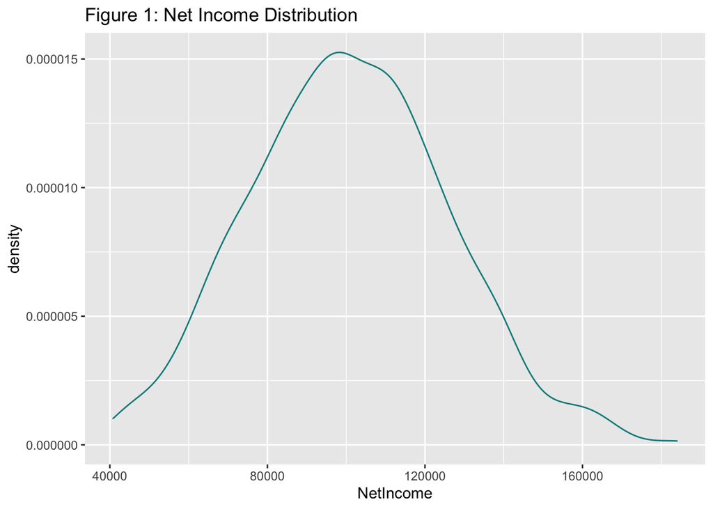

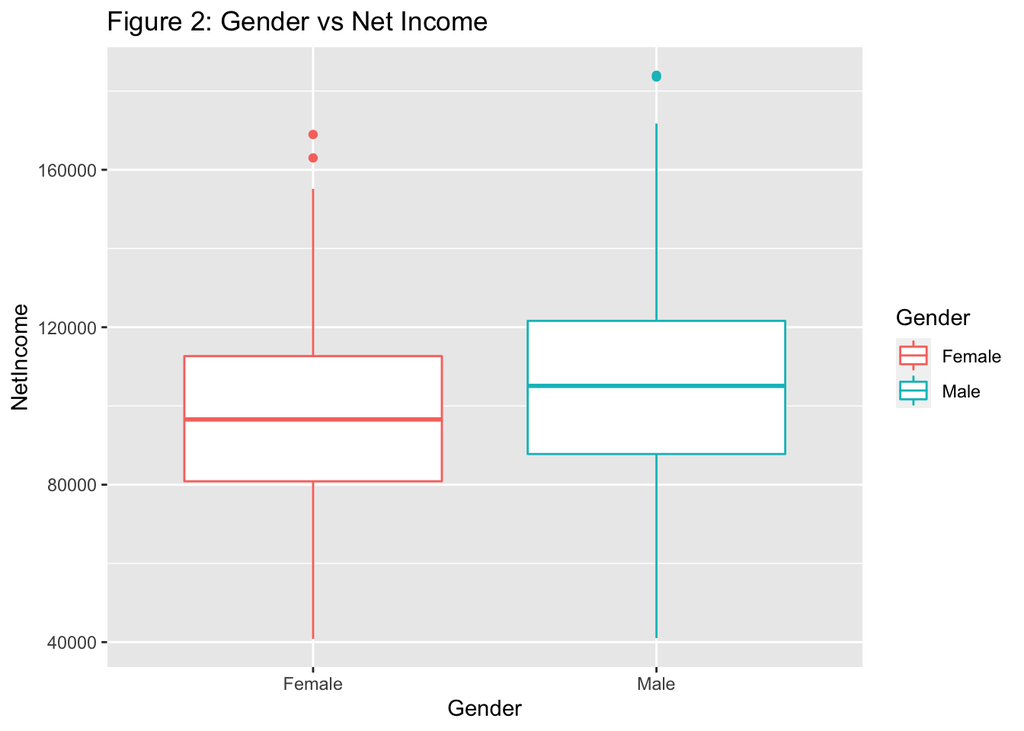

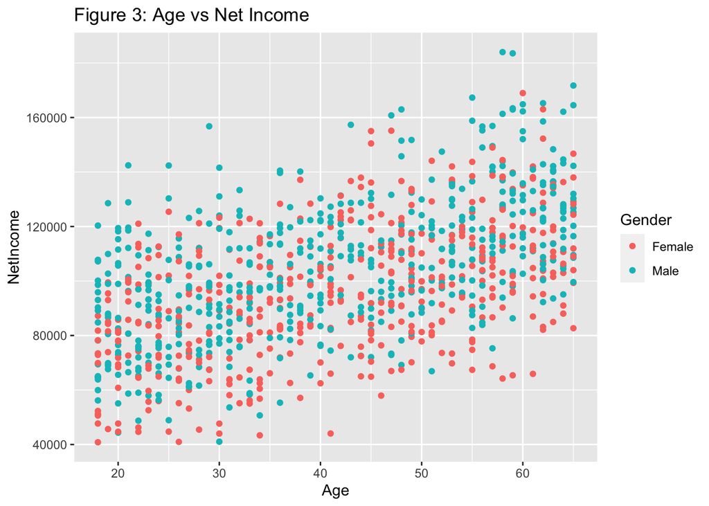

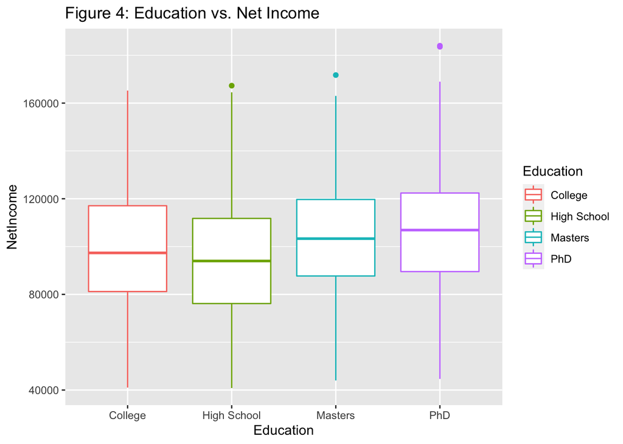

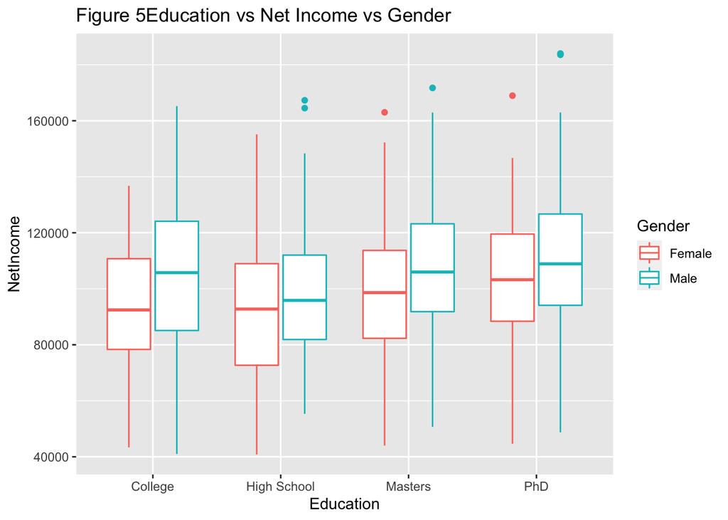

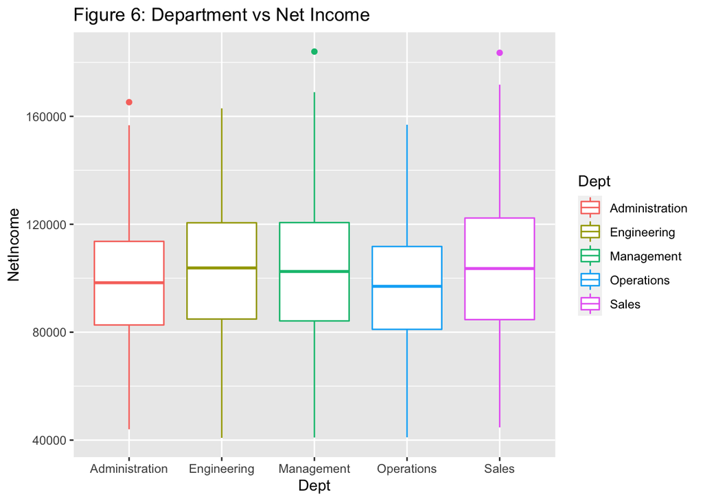

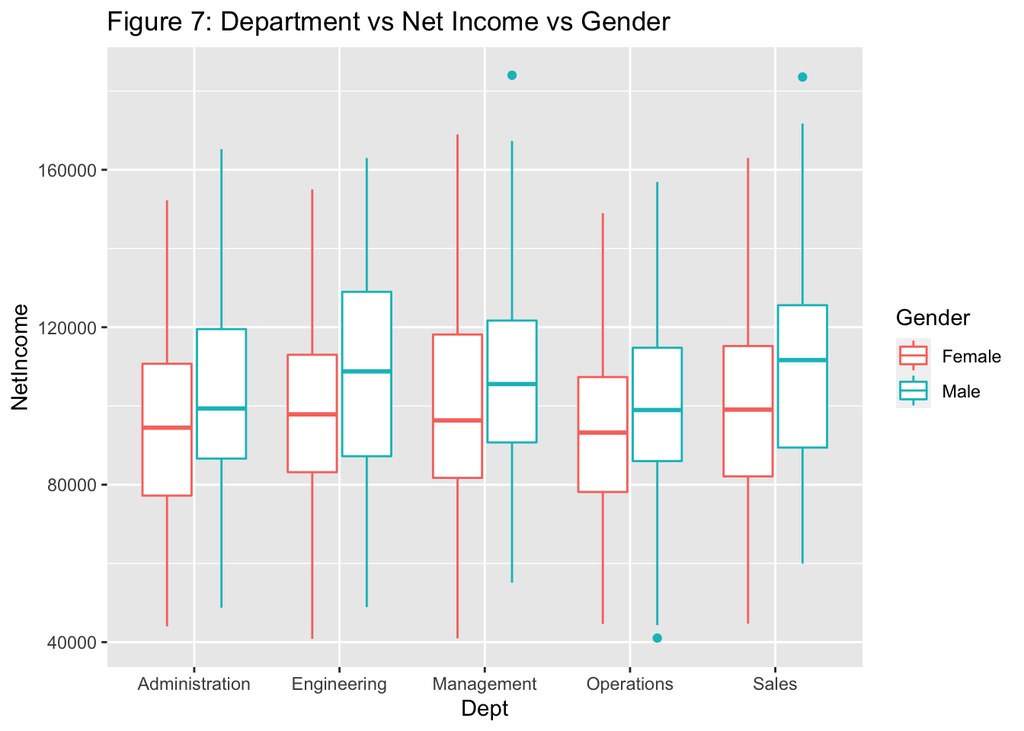

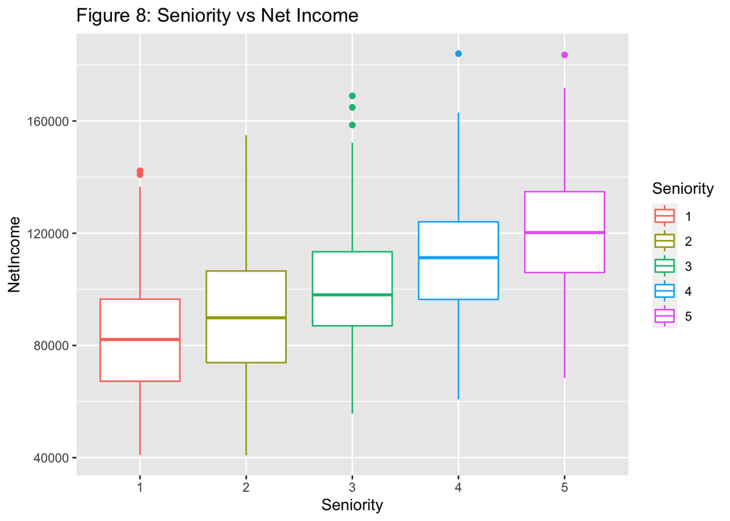

[figure not shown]

[output not shown]

# Part 2: Bonus vs Other Factors

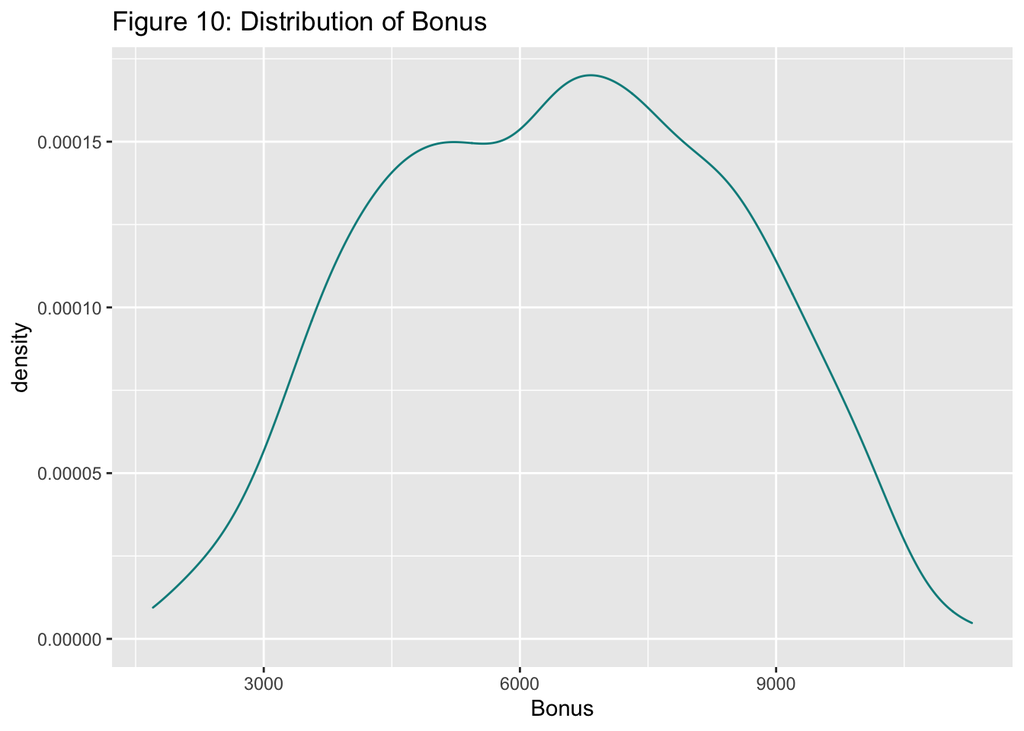

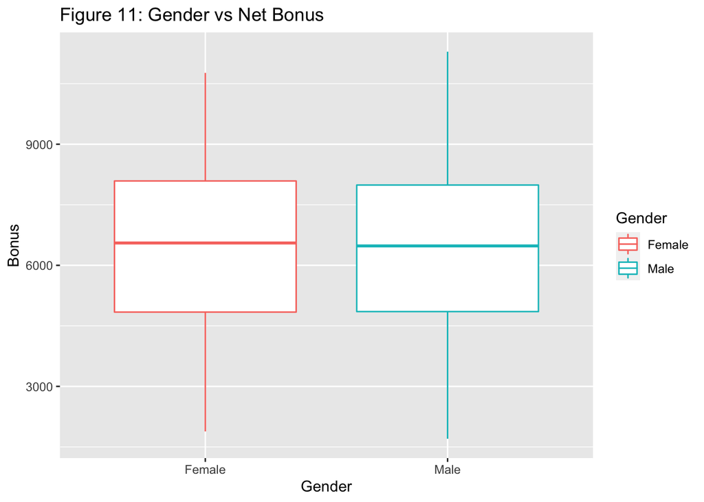

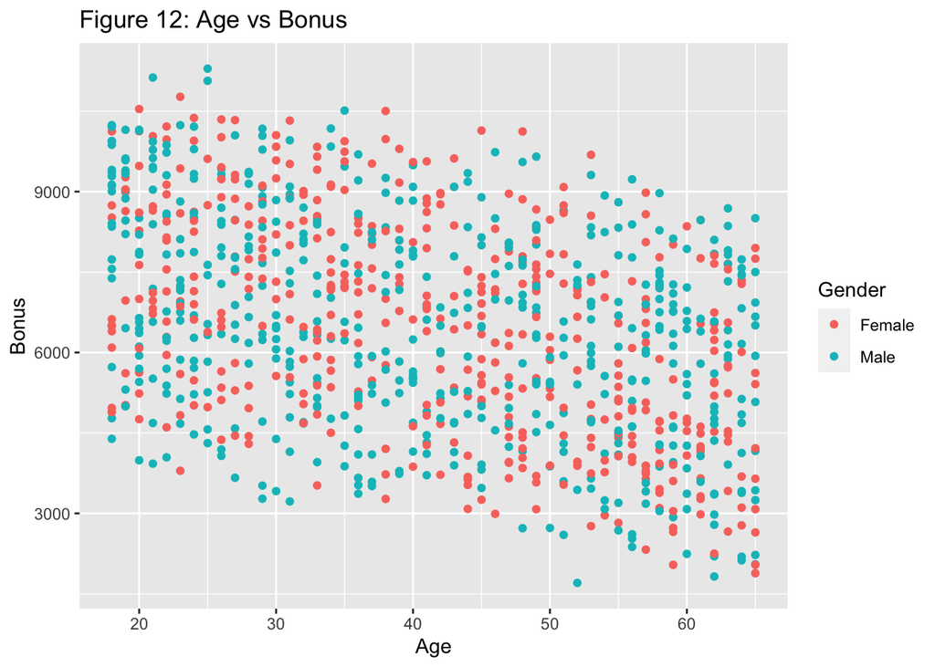

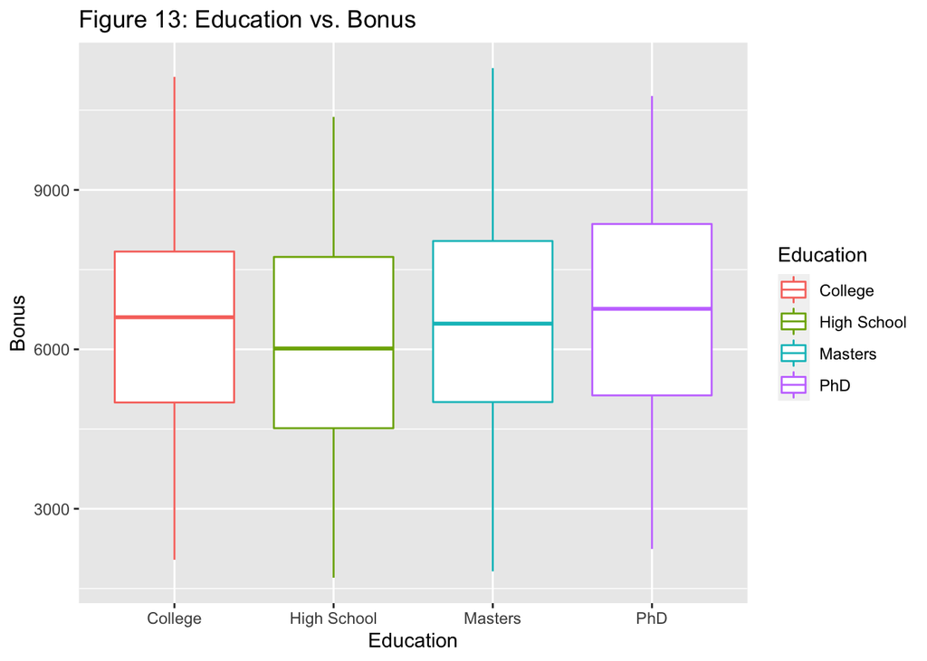

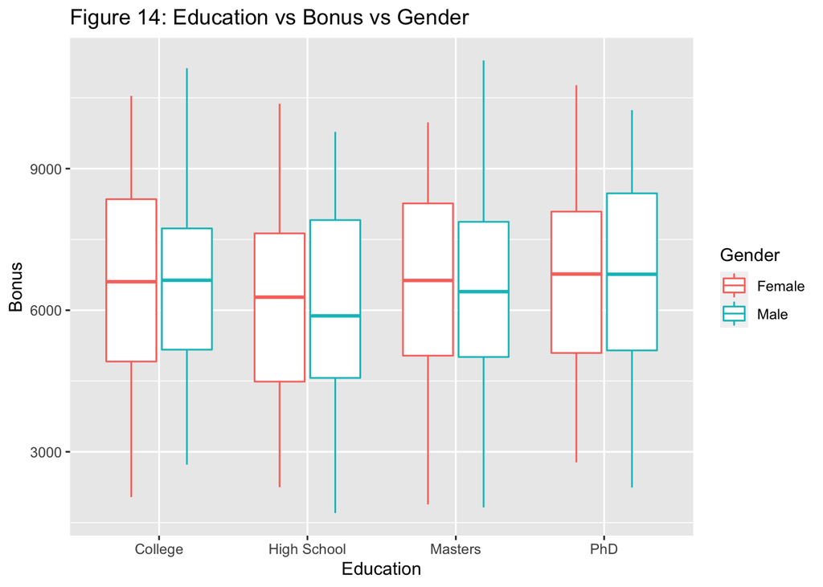

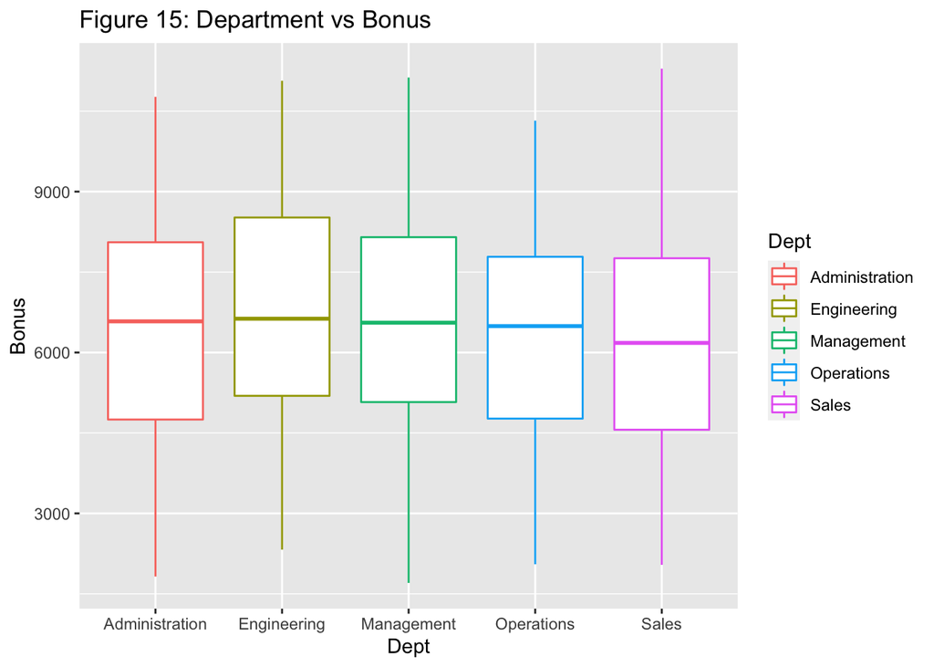

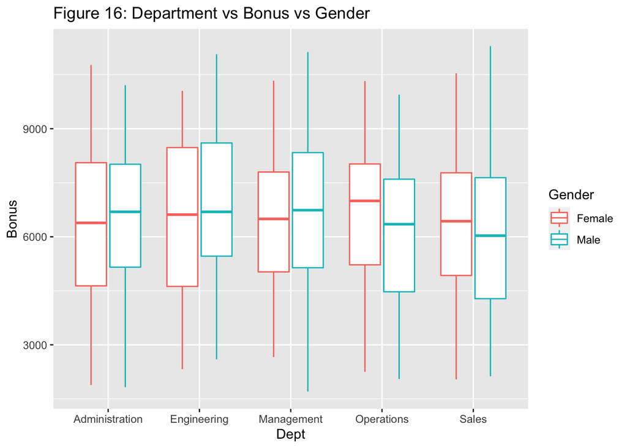

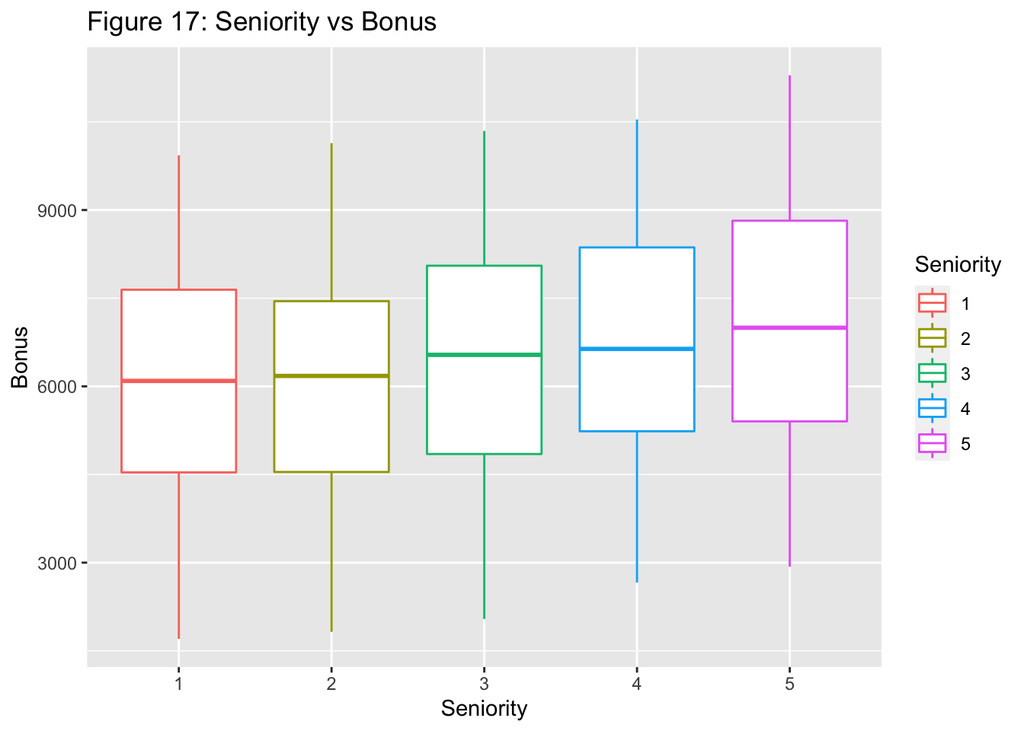

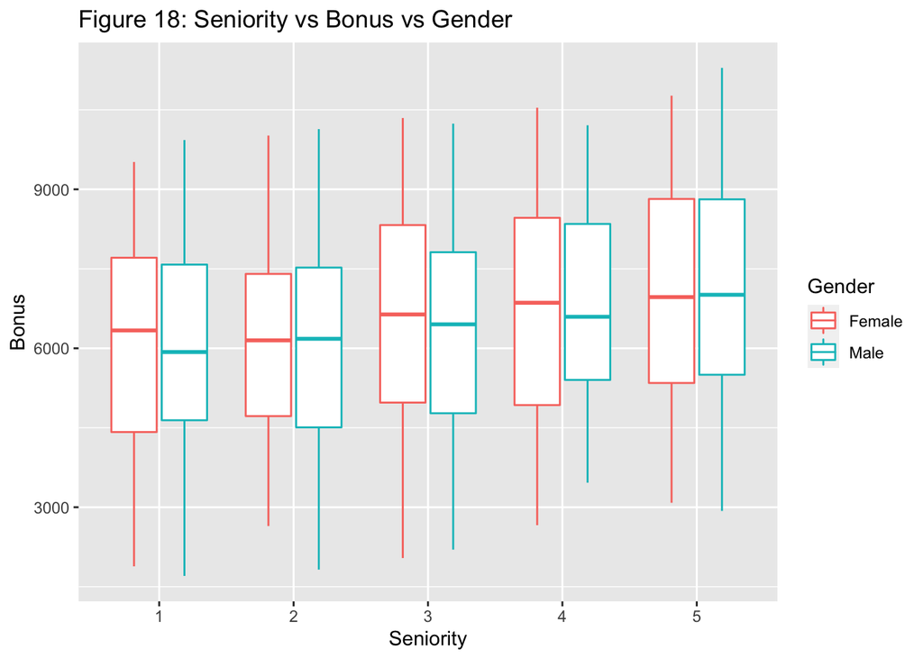